Charlotte’s rental market, often assumed to be steady, reveals a layered pricing system shaped by unit design, amenity mix, and neighborhood context. From Uptown’s compact studios to SouthPark’s larger suburban formats, rent behavior reflects more than square footage, it is influenced by branding, efficiency, and geographic positioning.

We began by grounding the analysis in descriptive statistics, which clarified the structural contours of rent and unit configuration. The geospatial phase then added a location‑aware lens, showing how density, boundaries, and clustering shape submarket identity and pricing logic. Building on these foundations, the regression phase quantified the statistical weight of size, amenities, and neighborhood effects. These models validated the structural relationships behind price per square foot (PPSF) and revealed how Charlotte’s market organized itself across scales, confirming that pricing patterns were systematic and interpretable rather than random.

# Key Takeaways from the Descriptive Phase

The descriptive statistics stage built the foundation for understanding Charlotte’s rental market, emphasizing its segmentation, variability, and intentional design. By examining measures of averages, spread, and correlation, we uncovered central patterns in rent levels and unit configurations.

Neighborhood analysis revealed clear geographic stratification. Uptown and West Charlotte stood out for premium pricing and volatility, while SouthPark and NoDa reflected more affordable and stable conditions.

PPSF trends highlighted unit-level segmentation. Studios and one-bedrooms consistently achieved higher PPSF, particularly in central districts, while larger units displayed greater variability, underscoring the trade-off between space and affordability.

Complex-level differences showed how developers shape offerings. Narrow rent ranges pointed to standardized layouts, whereas broader spreads suggested diverse unit mixes and flexible pricing strategies.

Examining square footage per bedroom revealed design intent. One-bedrooms provided the most space per bedroom, while three-bedrooms offered the least, reflecting efficiency goals and tenant targeting.

Outlier detection using IQR and z-scores sharpened the analysis, identifying atypical units and supporting both segmentation and data cleaning.

Correlation analysis quantified structural relationships, showing moderate links among rent, square footage, and bedroom count, while amenities played a secondary role in pricing.

Together, these findings confirm that Charlotte’s rental market is both varied and strategically organized. This statistical groundwork sets the stage for spatial and predictive modeling, beginning with geospatial analysis and extending into regression and decision tree frameworks.

# Key Takeaways from the Geospatial Phase

The geospatial analysis translated Charlotte’s rental data into a location-aware narrative, revealing how geography, density, and unit-level variation shape pricing logic and submarket identity.

Density maps highlighted concentrated rental activity in Uptown, South End, and transit-accessible corridors. These areas feature compact layouts, walkable environments, and elevated PPSF, reinforcing their role as Charlotte’s luxury core.

PPSF gradients revealed affordability corridors and pricing anomalies. Cooler zones such as Mallard Creek and Tyvola Tapestry signaled value-oriented inventory, while isolated high-PPSF units suggested branded offerings or transitional submarkets.

Overlaying neighborhood boundaries added interpretive precision. In some cases, PPSF aligned closely with neighborhood borders, validating expectations. In others, pricing spilled across boundaries, pointing to segmentation opportunities and emerging micro-neighborhoods.

DBSCAN clustering identified three distinct submarkets:

- Luxury Core: High-PPSF units in central, walkable districts
- Amenity-Rich Midrange: Moderately priced units in transitional zones
- Budget Fringe: Larger, lower-cost units in less central areas

Outlier detection flagged Moderna Liberty Row as a high-PPSF anomaly within a midrange zone, suggesting branded finishes or micro-location advantages. This may indicate early submarket transition or niche emergence.

Together, these spatial insights confirm that Charlotte’s rental market is not only statistically segmented but also geographically structured. The analysis supports location-sensitive design, targeted investment, and context-aware pricing strategies. This prepares the ground for regression modeling, which will quantify spatial dynamics and validate the structural logic behind PPSF.

# Key Takeaways from the Regression Phase

The regression analysis phase quantified Charlotte’s rental pricing logic, revealing a structured and multi‑dimensional market shaped by unit traits, amenity density, geographic desirability, and property‑level nuance. Across citywide, bedroom, neighborhood, and complex models, regressions delivered strong statistical performance and clarified how value is distributed at different scales.

At the citywide level, regressions explained over 95 percent of PPSF variation, confirming rent, square footage, and amenities as foundational drivers. Smaller units consistently commanded higher PPSF due to efficiency and concentrated demand, while features such as laundry, EV charging, and secure access added measurable premiums. Location effects remained stable, with Uptown, SouthPark, and South End carrying consistent pricing advantages, and standout complexes like Bond on Mint and Moderna Liberty Row reinforcing brand‑driven value.

Bedroom‑level regressions highlighted how pricing logic shifts with unit size. Studios and one‑bedrooms were highly sensitive to layout and amenity density, while larger formats reflected more selective valuation patterns. Bathrooms and certain amenities lost significance in larger units, underscoring how expectations evolve with scale.

Neighborhood‑level regressions surfaced spatial dynamics beyond citywide averages. While core predictors remained stable, amenity effects and complex representation varied by submarket. Uptown’s lower R² reflected a more diffuse pricing structure shaped by mixed‑use development and fragmented branding, with residual analysis confirming statistical reliability despite added complexity.

Complex‑level regressions provided a close‑up view of property‑specific pricing strategies. Some complexes emphasized rent thresholds, others prioritized layout efficiency or bundled amenities. Visual tools such as heatmaps and radar charts translated these distinct logics into intuitive narratives, making property‑level pricing both accessible and actionable.

Together, these regressions validated the broader model while elevating local nuances. They confirmed that Charlotte’s rental market operates with a high degree of internal logic, where pricing reflects consistent structural relationships across scales. For stakeholders, this layered framework supports precise valuation, targeted investment, and responsive policy design, ensuring the market is interpreted not as a monolith but as a mosaic of interlocking pricing strategies.

# Introduction to Decision Tree Modeling

In this section, we apply decision tree modeling to reveal the rule‑based pathways that shape rent and price per square foot (PPSF) in Charlotte’s multifamily rental market. Unlike regression, which quantifies continuous relationships, decision trees emphasize interpretability by segmenting the market into discrete thresholds and personas. Each split represents a decision rule, showing how combinations of size, rent, and complex identity interact to define pricing tiers.

We begin with citywide trees to establish the dominant drivers of rent and PPSF, then segment by unit size and complex identity to surface localized thresholds. This layered approach highlights both broad structural logic and the categorical distinctions that stakeholders encounter in practice. By mapping how units fall into value, midrange, and premium brackets, the trees provide a transparent framework for understanding market segmentation.

Decision trees serve as both explanatory and diagnostic tools. They expose nonlinear effects, identify behavioral thresholds, and translate statistical splits into intuitive narratives. By pairing descriptive statistics with rule‑based modeling, we move from observation to segmentation, showing how Charlotte’s rental landscape organizes itself not just through averages, but through branching pathways that mirror tenant decision‑making and market positioning.

```python
########>> INITIALIZE <<########

# === Basic Operation Libraries ===
import os
import sys
import ast
import datetime
import re
import time

# === Data Analysis Libraries ===
import pandas as pd
import numpy as np
import seaborn as sns
import matplotlib.pyplot as plt
import statsmodels.api as sm
import scipy.stats as stats
%matplotlib inline

# === Machine Learning Libraries ===
from sklearn.tree import DecisionTreeRegressor, plot_tree, export_text, _tree
from sklearn.model_selection import train_test_split
from sklearn.linear_model import LinearRegression

# === Display Settings for Jupyter ===
from IPython.display import display, HTML

# === Display Settings for Pandas ===
pd.set_option('display.html.table_schema', True)
pd.set_option('expand_frame_repr', True)
pd.set_option('display.max_colwidth', 200)
pd.options.display.html.use_mathjax = False

# === Manage Warnings ===
import warnings
warnings.filterwarnings('ignore')

# === Completion Timestamp ===
print("\n{:<5} : {}".format("Finished", str(datetime.datetime.now())))
```

```
Finished : 2025-11-25 16:06:03.892187
```

```python
apt = pd.read_csv("C:\\Users\\alexp\\Charlotte_Apartments.csv")
```

```python
apt.head()
```

|  | Complex | Address | Unit_Variant | Bedrooms | Bathrooms | Rent | Sqft | Amenities | Website | Neighborhood | ... | parking | ev_charging | elevator | secure_access | wifi | wifi_common | trash_pickup | renters_insurance | packages | recycling |
| --- | --- | --- | --- | --- | --- | --- | --- | --- | --- | --- | --- | --- | --- | --- | --- | --- | --- | --- | --- | --- | --- |
| 0 | Moderna Liberty Row | 7740 Liberty Row Dr, Charlotte, NC 28210 | S01 | 0.0 | 1.0 | 1469.0 | 651.0 | In-unit washer/dryer; High-speed internet in common areas; Controlled access bicycle storage; Additional storage available; Resort-style pool; 24-hour fitness center; Game room with billiards, pok... | https://www.moderalibertyrow.com/ | SouthPark | ... | 0 | 0 | 0 | 0 | 0 | 1 | 0 | 0 | 0 | 0 |
| 1 | Moderna Liberty Row | 7740 Liberty Row Dr, Charlotte, NC 28210 | A01 | 1.0 | 1.0 | 1707.0 | 747.0 | In-unit washer/dryer; High-speed internet in common areas; Controlled access bicycle storage; Additional storage available; Resort-style pool; 24-hour fitness center; Game room with billiards, pok... | https://www.moderalibertyrow.com/ | SouthPark | ... | 0 | 0 | 0 | 0 | 0 | 1 | 0 | 0 | 0 | 0 |
| 2 | Moderna Liberty Row | 7740 Liberty Row Dr, Charlotte, NC 28210 | A02 | 1.0 | 1.0 | 1707.0 | 747.0 | In-unit washer/dryer; High-speed internet in common areas; Controlled access bicycle storage; Additional storage available; Resort-style pool; 24-hour fitness center; Game room with billiards, pok... | https://www.moderalibertyrow.com/ | SouthPark | ... | 0 | 0 | 0 | 0 | 0 | 1 | 0 | 0 | 0 | 0 |
| 3 | Moderna Liberty Row | 7740 Liberty Row Dr, Charlotte, NC 28210 | A03 | 1.0 | 1.0 | 1532.0 | 801.0 | In-unit washer/dryer; High-speed internet in common areas; Controlled access bicycle storage; Additional storage available; Resort-style pool; 24-hour fitness center; Game room with billiards, pok... | https://www.moderalibertyrow.com/ | SouthPark | ... | 0 | 0 | 0 | 0 | 0 | 1 | 0 | 0 | 0 | 0 |
| 4 | Moderna Liberty Row | 7740 Liberty Row Dr, Charlotte, NC 28210 | A04 | 1.0 | 1.0 | 1766.0 | 861.0 | In-unit washer/dryer; High-speed internet in common areas; Controlled access bicycle storage; Additional storage available; Resort-style pool; 24-hour fitness center; Game room with billiards, pok... | https://www.moderalibertyrow.com/ | SouthPark | ... | 0 | 0 | 0 | 0 | 0 | 1 | 0 | 0 | 0 | 0 |

5 rows × 25 columns

# PPSF

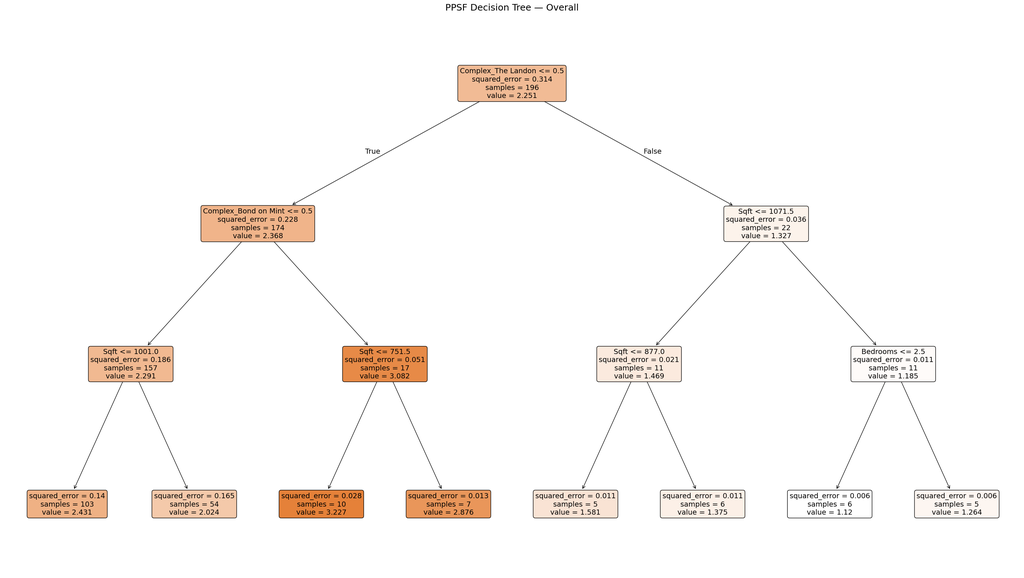

```
Complex_The Landon              0.560687
Complex_Bond on Mint            0.254396
Sqft                            0.183402
Bedrooms                        0.001516
Rent                            0.000000
Bathrooms                       0.000000
gym                             0.000000
laundry                         0.000000
parking                         0.000000
ev_charging                     0.000000
elevator                        0.000000
pool                            0.000000
secure_access                   0.000000
wifi                            0.000000
trash_pickup                    0.000000
wifi_common                     0.000000
renters_insurance               0.000000
packages                        0.000000
recycling                       0.000000
pets                            0.000000
Complex_Broadstone Craft        0.000000
Complex_Ello House              0.000000
Complex_Moderna Liberty Row     0.000000
Complex_Hawkins Press           0.000000
Complex_Novel Mallard Creek     0.000000
Complex_Solis Midtown           0.000000
Complex_The Henry               0.000000
Complex_The Leo LoSo            0.000000
Complex_The Perch               0.000000
Complex_Tyvola Tapestry         0.000000
Neighborhood_NoDa               0.000000
Neighborhood_South End          0.000000
Neighborhood_SouthPark          0.000000
Neighborhood_University City    0.000000
Neighborhood_Uptown             0.000000
Neighborhood_West Charlotte     0.000000
dtype: float64
R² for PPSF Decision Tree — Overall: 0.606
```

```python
# Drop non-predictive or text-heavy columns
apt_cleaned = apt.drop(columns=['Address', 'Unit_Variant', 'Amenities', 'Website'])

# Encode categorical columns
apt_encoded = pd.get_dummies(apt_cleaned, columns=['Complex', 'Neighborhood'], drop_first=False)

# Define target and features for PPSF (overall)
y_ppsf = apt_encoded['price_per_sqft']
X_ppsf = apt_encoded.drop(columns=['price_per_sqft'])

# Train/test split (distinct variable names for PPSF overall)
X_train_p, X_test_p, y_train_p, y_test_p = train_test_split(
    X_ppsf, y_ppsf, test_size=0.2, random_state=42
)

# Fit decision tree for PPSF overall
tree_ppsf = DecisionTreeRegressor(max_depth=3, min_samples_leaf=5, random_state=42)
tree_ppsf.fit(X_train_p, y_train_p)

# Visualize the tree
plt.figure(figsize=(36, 20))
plot_tree(
    tree_ppsf,
    feature_names=X_ppsf.columns,
    filled=True,
    rounded=True,
    fontsize=14
)
plt.title("PPSF Decision Tree — Overall", fontsize=18)
plt.show()

# Feature importance
importances_ppsf = pd.Series(tree_ppsf.feature_importances_, index=X_ppsf.columns)
print(importances_ppsf.sort_values(ascending=False))

# R² score for PPSF overall tree
r2_tree_ppsf = tree_ppsf.score(X_test_p, y_test_p)
print(f"R² for PPSF Decision Tree — Overall: {r2_tree_ppsf:.3f}")
```

## PPSF Decision Tree Leaf Summary

```python
def profile_tree_segments(tree, X, y, original_df, target_col, unit_col="Sqft", complex_col="Complex", neighborhood_col="Neighborhood"):
    # Get leaf node assignment for each row in X
    leaf_ids = tree.apply(X)

    profiles = []
    for leaf in np.unique(leaf_ids):
        mask = leaf_ids == leaf
        # Use the same index as X to select from original_df
        segment_df = original_df.loc[X.index[mask]]

        avg_target = segment_df[target_col].mean()
        avg_size   = segment_df[unit_col].mean()

        dominant_complex = segment_df[complex_col].mode()[0] if not segment_df.empty else None
        dominant_neigh   = segment_df[neighborhood_col].mode()[0] if not segment_df.empty else None

        profiles.append({
            "Leaf_ID": leaf,
            "Avg_" + target_col: round(avg_target, 2),
            "Typical_Size": round(avg_size, 0),
            "Dominant_Complex": dominant_complex,
            "Dominant_Neighborhood": dominant_neigh,
            "Count": len(segment_df)
        })

    return pd.DataFrame(profiles)

# Example usage for PPSF overall tree
segment_profiles_ppsf = profile_tree_segments(
    tree_ppsf,
    X_train_p,   # features used to fit
    y_train_p,   # target
    apt_cleaned, # original df with Sqft, Complex, Neighborhood
    target_col="price_per_sqft"
)

print(segment_profiles_ppsf)
```

```
   Leaf_ID  Avg_price_per_sqft  Typical_Size Dominant_Complex  \
0        3                2.43         721.0       Ello House
1        4                2.02        1205.0     The Leo LoSo
2        6                3.23         631.0     Bond on Mint
3        7                2.88        1134.0     Bond on Mint
4       10                1.58         769.0       The Landon
5       11                1.38         980.0       The Landon
6       13                1.12        1215.0       The Landon
7       14                1.26        1338.0       The Landon

  Dominant_Neighborhood  Count
0             South End    103
1             South End     54
2                Uptown     10
3                Uptown      7
4             SouthPark      5
5             SouthPark      6
6             SouthPark      6
7             SouthPark      5
```

Charlotte’s PPSF decision tree produces clear, leaf‑level personas that segment the rental market into distinct unit profiles. With an R² of 0.606, the model explains a meaningful share of variation in price per square foot, offering a transparent lens into how value clusters across complexes and neighborhoods.

Smaller South End units at Ello House emerge as a “starter premium” segment, averaging 721 square feet with PPSF near $\$2.43$. Larger layouts at Leo LoSo dilute PPSF to around $\$2.02$, reflecting the trade‑off between size and efficiency. Uptown’s Bond on Mint commands the highest premiums, with both small and large units priced well above $\$2.80$ PPSF, underscoring the strength of location over layout. In contrast, The Landon in SouthPark anchors the value tier, with units across sizes consistently priced between $\$1.12$ and $\$1.58$ PPSF.

The tree’s structure highlights categorical anchors and size thresholds rather than a wide spread of features. Complex identity and square footage dominate, while bedrooms, amenities, and neighborhood indicators play little role in segmentation. This simplicity makes the model easy to interpret: if it’s Ello House, expect a starter premium; if it’s Bond on Mint, expect Uptown luxury; if it’s The Landon, expect SouthPark value.

For stakeholders, the takeaway is straightforward. Regression quantified the global drivers first, showing how bedrooms, amenities, and size shape PPSF across the city. The decision tree then translated those drivers into personas, giving a narrative framework: South End starter premium, Uptown luxury, and SouthPark value. Together, the models provide both statistical rigor and intuitive segmentation, clarifying how Charlotte’s rental pricing is built.

## PPSF Decision Tree Rule Path

```python
tree_rules = export_text(tree_ppsf, feature_names=list(X_ppsf.columns))
print(tree_rules)
```

```
|--- Complex_The Landon <= 0.50
|   |--- Complex_Bond on Mint <= 0.50
|   |   |--- Sqft <= 1001.00
|   |   |   |--- value: [2.43]
|   |   |--- Sqft >  1001.00
|   |   |   |--- value: [2.02]
|   |--- Complex_Bond on Mint >  0.50
|   |   |--- Sqft <= 751.50
|   |   |   |--- value: [3.23]
|   |   |--- Sqft >  751.50
|   |   |   |--- value: [2.88]
|--- Complex_The Landon >  0.50
|   |--- Sqft <= 1071.50
|   |   |--- Sqft <= 877.00
|   |   |   |--- value: [1.58]
|   |   |--- Sqft >  877.00
|   |   |   |--- value: [1.38]
|   |--- Sqft >  1071.50
|   |   |--- Bedrooms <= 2.50
|   |   |   |--- value: [1.12]
|   |   |--- Bedrooms >  2.50
|   |   |   |--- value: [1.26]
```

Charlotte’s PPSF decision tree produces a clean set of rules that segment units into distinct pricing personas. The model begins by splitting on complex identity, then refines predictions with square footage and, in some cases, bedroom count. Each leaf represents a final segment with its own average PPSF.

The first split separates The Landon from all other complexes. Non‑Landon units divide further by Bond on Mint and size. Smaller South End units not in Bond on Mint average $\$2.43$ PPSF, while larger layouts fall to $\$2.02$. Bond on Mint defines the Uptown premium, with small units reaching $\$3.23$ PPSF and larger ones at $\$2.88$.

Within The Landon, square footage drives the next segmentation. Smaller SouthPark units average $\$1.58$ PPSF, mid‑sized units $\$1.38$, and larger layouts range between $\$1.12$ and $\$1.26$ depending on bedroom count. Across all sizes, The Landon consistently anchors the value tier.

The structure highlights categorical anchors and size thresholds rather than a wide spread of features. Complex identity dominates, square footage refines, and bedrooms play only a minor role. Amenities and neighborhood indicators contribute little, reinforcing the tree’s simplicity.

For stakeholders, the narrative is straightforward. Regression was run first to establish the global drivers of PPSF, quantifying the effects of bedrooms, amenities, and square footage. The decision tree then builds on that foundation, translating those drivers into personas that are easy to interpret: South End starter premium, South End mid‑range, Uptown luxury, and SouthPark value. Together, the models provide both statistical rigor and intuitive segmentation, clarifying how Charlotte’s rental pricing is structured.

## PPSF Decision Tree If-Then Rules

```python
def extract_leaf_rules(tree, feature_names):
    tree_ = tree.tree_
    feature_name = [
        feature_names[i] if i != _tree.TREE_UNDEFINED else "undefined!"
        for i in tree_.feature
    ]

    paths = []
    path = []

    def recurse(node, path, paths):
        if tree_.feature[node] != _tree.TREE_UNDEFINED:
            name = feature_name[node]
            threshold = tree_.threshold[node]
            left_path = list(path)
            left_path.append(f"{name} <= {threshold:.1f}")
            recurse(tree_.children_left[node], left_path, paths)

            right_path = list(path)
            right_path.append(f"{name} > {threshold:.1f}")
            recurse(tree_.children_right[node], right_path, paths)
        else:
            value = tree_.value[node][0][0]
            rule = " AND ".join(path)
            paths.append((rule, round(value, 3)))

    recurse(0, path, paths)
    return paths

# Run and print
rules = extract_leaf_rules(tree_ppsf, list(X_ppsf.columns))
for rule, value in rules:
    print(f"If {rule} → PPSF ≈ {value}")
```

```
If Complex_The Landon <= 0.5 AND Complex_Bond on Mint <= 0.5 AND Sqft <= 1001.0 → PPSF ≈ 2.431
If Complex_The Landon <= 0.5 AND Complex_Bond on Mint <= 0.5 AND Sqft > 1001.0 → PPSF ≈ 2.024
If Complex_The Landon <= 0.5 AND Complex_Bond on Mint > 0.5 AND Sqft <= 751.5 → PPSF ≈ 3.227
If Complex_The Landon <= 0.5 AND Complex_Bond on Mint > 0.5 AND Sqft > 751.5 → PPSF ≈ 2.876
If Complex_The Landon > 0.5 AND Sqft <= 1071.5 AND Sqft <= 877.0 → PPSF ≈ 1.581
If Complex_The Landon > 0.5 AND Sqft <= 1071.5 AND Sqft > 877.0 → PPSF ≈ 1.375
If Complex_The Landon > 0.5 AND Sqft > 1071.5 AND Bedrooms <= 2.5 → PPSF ≈ 1.12
If Complex_The Landon > 0.5 AND Sqft > 1071.5 AND Bedrooms > 2.5 → PPSF ≈ 1.264
```

## PPSF Small

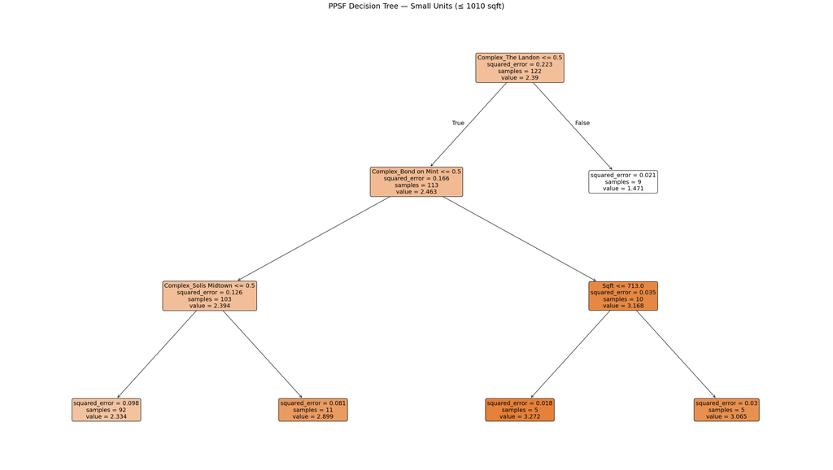

```
Complex_The Landon              0.484874
Complex_Bond on Mint            0.322976
Complex_Solis Midtown           0.185790
Sqft                            0.006360
Rent                            0.000000
Bathrooms                       0.000000
Bedrooms                        0.000000
laundry                         0.000000
parking                         0.000000
ev_charging                     0.000000
gym                             0.000000
pool                            0.000000
secure_access                   0.000000
wifi                            0.000000
trash_pickup                    0.000000
wifi_common                     0.000000
renters_insurance               0.000000
packages                        0.000000
elevator                        0.000000
pets                            0.000000
Complex_Broadstone Craft        0.000000
recycling                       0.000000
Complex_Ello House              0.000000
Complex_Hawkins Press           0.000000
Complex_Novel Mallard Creek     0.000000
Complex_Moderna Liberty Row     0.000000
Complex_The Henry               0.000000
Complex_The Leo LoSo            0.000000
Complex_The Perch               0.000000
Complex_Tyvola Tapestry         0.000000
Neighborhood_NoDa               0.000000
Neighborhood_South End          0.000000
Neighborhood_SouthPark          0.000000
Neighborhood_University City    0.000000
Neighborhood_Uptown             0.000000
Neighborhood_West Charlotte     0.000000
dtype: float64

📈 R² for PPSF Tree — Small Units: 0.507
```

```python
# Drop non-predictive or text-heavy columns
apt_cleaned = apt.drop(columns=['Address', 'Unit_Variant', 'Amenities', 'Website'])

# Encode categorical columns
apt_encoded = pd.get_dummies(apt_cleaned, columns=['Complex', 'Neighborhood'], drop_first=False)

# Filter for small units (≤ 1010 sqft)
apt_small = apt_encoded[apt_encoded['Sqft'] <= 1010]

# Define target and features for PPSF (small units)
y_small = apt_small['price_per_sqft']
X_small = apt_small.drop(columns=['price_per_sqft'])

# Train/test split (distinct variable names for small units)
X_train_s, X_test_s, y_train_s, y_test_s = train_test_split(
    X_small, y_small, test_size=0.2, random_state=42
)

# Fit decision tree for PPSF (small units)
tree_small = DecisionTreeRegressor(max_depth=3, min_samples_leaf=5, random_state=42)
tree_small.fit(X_train_s, y_train_s)

# Visualize the tree
plt.figure(figsize=(36, 20))
plot_tree(
    tree_small,
    feature_names=X_small.columns,
    filled=True,
    rounded=True,
    fontsize=14
)
plt.title("PPSF Decision Tree — Small Units (≤ 1010 sqft)", fontsize=18)
plt.show()

# Feature importance
importances_small = pd.Series(tree_small.feature_importances_, index=X_small.columns)
print(importances_small.sort_values(ascending=False))

# Calculate R² score for PPSF tree (small units)
r2_tree_small = tree_small.score(X_test_s, y_test_s)

# R² score for PPSF tree (small units)
print(f"\n📈 R² for PPSF Tree — Small Units: {r2_tree_small:.3f}")
```

Charlotte’s PPSF decision tree for small units (< 1010 sqft) reveals a sparse, rule‑based structure that segments the compact rental market with surprising clarity. Complex identity drives nearly all predictive power, with The Landon, Bond on Mint, and Solis Midtown anchoring distinct pricing tiers. Square footage plays a minor role, used only to refine predictions within Bond on Mint. All other features—including bedrooms, bathrooms, amenities, and neighborhood indicators—are excluded from the tree’s logic.

The first split isolates The Landon, which defines the SouthPark value tier with PPSF averaging $\$1.47$. Units outside The Landon divide further by complex. Bond on Mint anchors the Uptown luxury segment, with smaller units priced at $\$3.27$ PPSF and larger layouts at $\$3.07$. Solis Midtown forms a distinct premium tier at $\$2.90$ PPSF. All other small units, primarily in South End, fall into a mid‑range segment around $\$2.33$ PPSF.

This structure highlights the dominance of categorical anchors over granular features. The tree uses just four variables to explain PPSF variation, yielding an R² of 0.507. Its simplicity makes it easy to interpret: if it’s The Landon, expect SouthPark value; if it’s Bond on Mint, expect Uptown luxury; if it’s Solis Midtown, expect a premium tier; otherwise, expect South End mid‑range.

For stakeholders, the takeaway is clear. Regression was run first to quantify the global effects of layout, amenities, and size. The decision tree then distilled those effects into personas that segment the small-unit market with precision. Together, the models provide both statistical rigor and intuitive clarity, showing how Charlotte’s compact rentals are priced.